# Risk Factor Analysis

## Outcome Variable

**Outcome Variable:** sstunted

## Predictor Variables

**Intervention Variable:** predexfd6

**Adjustment Set:**

unadjusted

## Stratifying Variables

The analysis was stratified on these variable(s):

- agecat
- studyid
- country

## Data Summary

| agecat | studyid | country | predexfd6 | sstunted | n_cell | n |
| --- | --- | --- | --- | --- | --- | --- |
| Birth | ki0047075b-MAL-ED | BANGLADESH | 0 | 0 | 108 | 231 |
| Birth | ki0047075b-MAL-ED | BANGLADESH | 0 | 1 | 4 | 231 |
| Birth | ki0047075b-MAL-ED | BANGLADESH | 1 | 0 | 117 | 231 |
| Birth | ki0047075b-MAL-ED | BANGLADESH | 1 | 1 | 2 | 231 |
| Birth | ki0047075b-MAL-ED | BRAZIL | 0 | 0 | 142 | 175 |
| Birth | ki0047075b-MAL-ED | BRAZIL | 0 | 1 | 6 | 175 |
| Birth | ki0047075b-MAL-ED | BRAZIL | 1 | 0 | 26 | 175 |
| Birth | ki0047075b-MAL-ED | BRAZIL | 1 | 1 | 1 | 175 |
| Birth | ki0047075b-MAL-ED | INDIA | 0 | 0 | 170 | 190 |
| Birth | ki0047075b-MAL-ED | INDIA | 0 | 1 | 5 | 190 |
| Birth | ki0047075b-MAL-ED | INDIA | 1 | 0 | 13 | 190 |
| Birth | ki0047075b-MAL-ED | INDIA | 1 | 1 | 2 | 190 |
| Birth | ki0047075b-MAL-ED | NEPAL | 0 | 0 | 142 | 170 |
| Birth | ki0047075b-MAL-ED | NEPAL | 0 | 1 | 5 | 170 |
| Birth | ki0047075b-MAL-ED | NEPAL | 1 | 0 | 22 | 170 |
| Birth | ki0047075b-MAL-ED | NEPAL | 1 | 1 | 1 | 170 |
| Birth | ki0047075b-MAL-ED | PERU | 0 | 0 | 146 | 256 |
| Birth | ki0047075b-MAL-ED | PERU | 0 | 1 | 4 | 256 |
| Birth | ki0047075b-MAL-ED | PERU | 1 | 0 | 104 | 256 |
| Birth | ki0047075b-MAL-ED | PERU | 1 | 1 | 2 | 256 |
| Birth | ki0047075b-MAL-ED | SOUTH AFRICA | 0 | 0 | 207 | 211 |
| Birth | ki0047075b-MAL-ED | SOUTH AFRICA | 0 | 1 | 1 | 211 |
| Birth | ki0047075b-MAL-ED | SOUTH AFRICA | 1 | 0 | 3 | 211 |
| Birth | ki0047075b-MAL-ED | SOUTH AFRICA | 1 | 1 | 0 | 211 |
| Birth | ki0047075b-MAL-ED | TANZANIA, UNITED REPUBLIC OF | 0 | 0 | 113 | 119 |
| Birth | ki0047075b-MAL-ED | TANZANIA, UNITED REPUBLIC OF | 0 | 1 | 5 | 119 |
| Birth | ki0047075b-MAL-ED | TANZANIA, UNITED REPUBLIC OF | 1 | 0 | 1 | 119 |
| Birth | ki0047075b-MAL-ED | TANZANIA, UNITED REPUBLIC OF | 1 | 1 | 0 | 119 |
| Birth | ki1000108-CMC-V-BCS-2002 | INDIA | 0 | 0 | 0 | 7 |
| Birth | ki1000108-CMC-V-BCS-2002 | INDIA | 0 | 1 | 0 | 7 |

[output cut: 158 more lines]

The following strata were considered:

- agecat: 24 months, studyid: ki0047075b-MAL-ED, country: BANGLADESH
- agecat: 24 months, studyid: ki0047075b-MAL-ED, country: BRAZIL
- agecat: 24 months, studyid: ki0047075b-MAL-ED, country: INDIA
- agecat: 24 months, studyid: ki0047075b-MAL-ED, country: NEPAL
- agecat: 24 months, studyid: ki0047075b-MAL-ED, country: PERU
- agecat: 24 months, studyid: ki0047075b-MAL-ED, country: SOUTH AFRICA
- agecat: 24 months, studyid: ki0047075b-MAL-ED, country: TANZANIA, UNITED REPUBLIC OF
- agecat: 24 months, studyid: ki1000108-CMC-V-BCS-2002, country: INDIA
- agecat: 24 months, studyid: ki1000108-IRC, country: INDIA
- agecat: 24 months, studyid: ki1017093b-PROVIDE, country: BANGLADESH
- agecat: 24 months, studyid: ki1101329-Keneba, country: GAMBIA
- agecat: 24 months, studyid: ki1113344-GMS-Nepal, country: NEPAL
- agecat: 24 months, studyid: ki1148112-LCNI-5, country: MALAWI
- agecat: 24 months, studyid: kiGH5241-JiVitA-3, country: BANGLADESH
- agecat: 24 months, studyid: kiGH5241-JiVitA-4, country: BANGLADESH
- agecat: 6 months, studyid: ki0047075b-MAL-ED, country: BANGLADESH
- agecat: 6 months, studyid: ki0047075b-MAL-ED, country: BRAZIL
- agecat: 6 months, studyid: ki0047075b-MAL-ED, country: INDIA
- agecat: 6 months, studyid: ki0047075b-MAL-ED, country: NEPAL
- agecat: 6 months, studyid: ki0047075b-MAL-ED, country: PERU
- agecat: 6 months, studyid: ki0047075b-MAL-ED, country: SOUTH AFRICA
- agecat: 6 months, studyid: ki0047075b-MAL-ED, country: TANZANIA, UNITED REPUBLIC OF
- agecat: 6 months, studyid: ki1000108-CMC-V-BCS-2002, country: INDIA
- agecat: 6 months, studyid: ki1000108-IRC, country: INDIA
- agecat: 6 months, studyid: ki1000109-EE, country: PAKISTAN
- agecat: 6 months, studyid: ki1000304b-SAS-CompFeed, country: INDIA
- agecat: 6 months, studyid: ki1000304b-SAS-FoodSuppl, country: INDIA
- agecat: 6 months, studyid: ki1017093b-PROVIDE, country: BANGLADESH
- agecat: 6 months, studyid: ki1101329-Keneba, country: GAMBIA
- agecat: 6 months, studyid: ki1113344-GMS-Nepal, country: NEPAL
- agecat: 6 months, studyid: ki1148112-LCNI-5, country: MALAWI
- agecat: 6 months, studyid: kiGH5241-JiVitA-3, country: BANGLADESH
- agecat: 6 months, studyid: kiGH5241-JiVitA-4, country: BANGLADESH
- agecat: Birth, studyid: ki0047075b-MAL-ED, country: BANGLADESH
- agecat: Birth, studyid: ki0047075b-MAL-ED, country: BRAZIL
- agecat: Birth, studyid: ki0047075b-MAL-ED, country: INDIA
- agecat: Birth, studyid: ki0047075b-MAL-ED, country: NEPAL
- agecat: Birth, studyid: ki0047075b-MAL-ED, country: PERU
- agecat: Birth, studyid: ki0047075b-MAL-ED, country: SOUTH AFRICA
- agecat: Birth, studyid: ki0047075b-MAL-ED, country: TANZANIA, UNITED REPUBLIC OF
- agecat: Birth, studyid: ki1000108-CMC-V-BCS-2002, country: INDIA
- agecat: Birth, studyid: ki1000108-IRC, country: INDIA
- agecat: Birth, studyid: ki1000109-EE, country: PAKISTAN
- agecat: Birth, studyid: ki1000304b-SAS-CompFeed, country: INDIA
- agecat: Birth, studyid: ki1101329-Keneba, country: GAMBIA
- agecat: Birth, studyid: kiGH5241-JiVitA-3, country: BANGLADESH
- agecat: Birth, studyid: kiGH5241-JiVitA-4, country: BANGLADESH

### Dropped Strata

Some strata were dropped due to rare outcomes:

- agecat: Birth, studyid: ki0047075b-MAL-ED, country: BANGLADESH
- agecat: Birth, studyid: ki0047075b-MAL-ED, country: BRAZIL
- agecat: Birth, studyid: ki0047075b-MAL-ED, country: INDIA
- agecat: Birth, studyid: ki0047075b-MAL-ED, country: NEPAL
- agecat: Birth, studyid: ki0047075b-MAL-ED, country: PERU
- agecat: Birth, studyid: ki0047075b-MAL-ED, country: SOUTH AFRICA
- agecat: Birth, studyid: ki0047075b-MAL-ED, country: TANZANIA, UNITED REPUBLIC OF
- agecat: Birth, studyid: ki1000108-CMC-V-BCS-2002, country: INDIA
- agecat: Birth, studyid: ki1000108-IRC, country: INDIA
- agecat: Birth, studyid: ki1000109-EE, country: PAKISTAN
- agecat: Birth, studyid: ki1000304b-SAS-CompFeed, country: INDIA
- agecat: 6 months, studyid: ki0047075b-MAL-ED, country: BANGLADESH
- agecat: 6 months, studyid: ki0047075b-MAL-ED, country: BRAZIL
- agecat: 6 months, studyid: ki0047075b-MAL-ED, country: INDIA
- agecat: 6 months, studyid: ki0047075b-MAL-ED, country: NEPAL
- agecat: 6 months, studyid: ki0047075b-MAL-ED, country: PERU
- agecat: 6 months, studyid: ki0047075b-MAL-ED, country: SOUTH AFRICA
- agecat: 6 months, studyid: ki0047075b-MAL-ED, country: TANZANIA, UNITED REPUBLIC OF
- agecat: 6 months, studyid: ki1000108-CMC-V-BCS-2002, country: INDIA
- agecat: 6 months, studyid: ki1000108-IRC, country: INDIA
- agecat: 6 months, studyid: ki1000304b-SAS-CompFeed, country: INDIA
- agecat: 6 months, studyid: ki1000304b-SAS-FoodSuppl, country: INDIA
- agecat: 6 months, studyid: ki1017093b-PROVIDE, country: BANGLADESH
- agecat: 6 months, studyid: ki1148112-LCNI-5, country: MALAWI
- agecat: 24 months, studyid: ki0047075b-MAL-ED, country: BRAZIL
- agecat: 24 months, studyid: ki0047075b-MAL-ED, country: INDIA
- agecat: 24 months, studyid: ki0047075b-MAL-ED, country: NEPAL
- agecat: 24 months, studyid: ki0047075b-MAL-ED, country: PERU
- agecat: 24 months, studyid: ki0047075b-MAL-ED, country: SOUTH AFRICA
- agecat: 24 months, studyid: ki0047075b-MAL-ED, country: TANZANIA, UNITED REPUBLIC OF
- agecat: 24 months, studyid: ki1000108-CMC-V-BCS-2002, country: INDIA
- agecat: 24 months, studyid: ki1000108-IRC, country: INDIA
- agecat: 24 months, studyid: ki1148112-LCNI-5, country: MALAWI

## Methods Detail

We’re interested in the causal parameters $E[Y_a]$ for all values of $a \in \mathcal{A}$. These parameters represent the mean outcome if, possibly contrary to fact, we intervened to set all units to have $A=a$. Under the randomization and positivity assumptions, these are identified by the statistical parameters $\psi_a=E_W[E_{Y|A,W}(Y|A=a,W)]$. In addition, we’re interested in the mean of $Y$, $E[Y]$ under no intervention (the observed mean). We will estimate these parameters by using SuperLearner to fit the relevant likelihood factors – $E_{Y|A,W}(Y|A=a,W)$ and $p(A=a|W)$, and then updating our likelihood fit using a joint TMLE.

For unadjusted analyses ($W=\{\}$), initial likelihoods were estimated using Lrnr_glm to estimate the simple $E(Y|A)$ and Lrnr_mean to estimate $p(A)$. For adjusted analyses, a small library containing Lrnr_glmnet, Lrnr_xgboost, and Lrnr_mean was used.

Having estimated these parameters, we will then use the delta method to estimate relative risks and attributable risks relative to a prespecified baseline level of $A$.

# Results Detail

## Results Plots

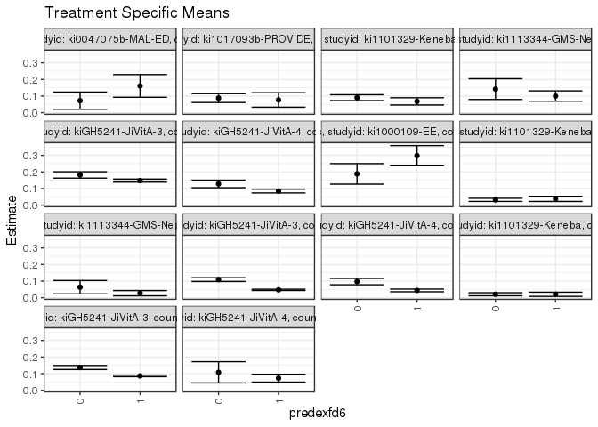

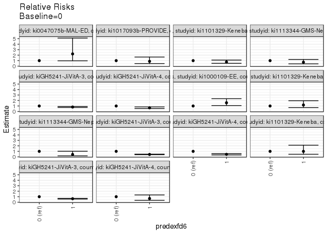

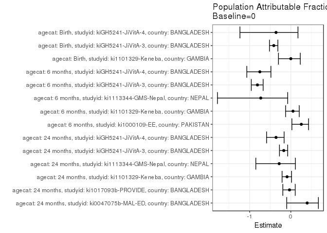

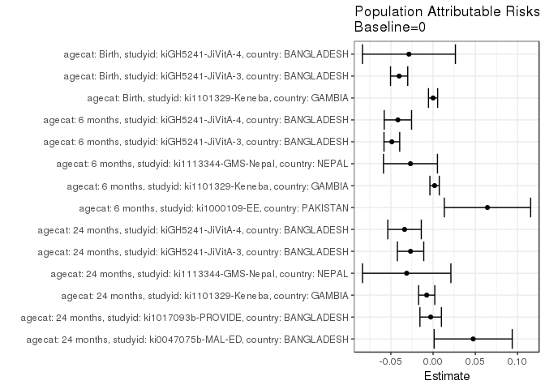

## Results Table

### Parameter: TSM

| agecat | studyid | country | intervention_level | baseline_level | estimate | ci_lower | ci_upper |
| --- | --- | --- | --- | --- | --- | --- | --- |
| Birth | ki1101329-Keneba | GAMBIA | 0 | NA | 0.0207197 | 0.0114969 | 0.0299426 |
| Birth | ki1101329-Keneba | GAMBIA | 1 | NA | 0.0206612 | 0.0079839 | 0.0333384 |
| Birth | kiGH5241-JiVitA-3 | BANGLADESH | 0 | NA | 0.1372303 | 0.1251405 | 0.1493201 |
| Birth | kiGH5241-JiVitA-3 | BANGLADESH | 1 | NA | 0.0864467 | 0.0817309 | 0.0911626 |
| Birth | kiGH5241-JiVitA-4 | BANGLADESH | 0 | NA | 0.1081081 | 0.0441369 | 0.1720793 |
| Birth | kiGH5241-JiVitA-4 | BANGLADESH | 1 | NA | 0.0726979 | 0.0492243 | 0.0961715 |
| 6 months | ki1000109-EE | PAKISTAN | 0 | NA | 0.1883117 | 0.1264808 | 0.2501426 |
| 6 months | ki1000109-EE | PAKISTAN | 1 | NA | 0.2981651 | 0.2373586 | 0.3589717 |
| 6 months | ki1101329-Keneba | GAMBIA | 0 | NA | 0.0317700 | 0.0223132 | 0.0412268 |
| 6 months | ki1101329-Keneba | GAMBIA | 1 | NA | 0.0375427 | 0.0221481 | 0.0529372 |
| 6 months | ki1113344-GMS-Nepal | NEPAL | 0 | NA | 0.0633803 | 0.0232695 | 0.1034910 |
| 6 months | ki1113344-GMS-Nepal | NEPAL | 1 | NA | 0.0272277 | 0.0113435 | 0.0431120 |
| 6 months | kiGH5241-JiVitA-3 | BANGLADESH | 0 | NA | 0.1089910 | 0.0976945 | 0.1202875 |
| 6 months | kiGH5241-JiVitA-3 | BANGLADESH | 1 | NA | 0.0474174 | 0.0437091 | 0.0511256 |
| 6 months | kiGH5241-JiVitA-4 | BANGLADESH | 0 | NA | 0.0970874 | 0.0778348 | 0.1163400 |
| 6 months | kiGH5241-JiVitA-4 | BANGLADESH | 1 | NA | 0.0438175 | 0.0357259 | 0.0519091 |
| 24 months | ki0047075b-MAL-ED | BANGLADESH | 0 | NA | 0.0721649 | 0.0205468 | 0.1237831 |
| 24 months | ki0047075b-MAL-ED | BANGLADESH | 1 | NA | 0.1607143 | 0.0925334 | 0.2288952 |
| 24 months | ki1017093b-PROVIDE | BANGLADESH | 0 | NA | 0.0877598 | 0.0610861 | 0.1144335 |
| 24 months | ki1017093b-PROVIDE | BANGLADESH | 1 | NA | 0.0763889 | 0.0329676 | 0.1198102 |
| 24 months | ki1101329-Keneba | GAMBIA | 0 | NA | 0.0901804 | 0.0724033 | 0.1079574 |
| 24 months | ki1101329-Keneba | GAMBIA | 1 | NA | 0.0679612 | 0.0462174 | 0.0897050 |
| 24 months | ki1113344-GMS-Nepal | NEPAL | 0 | NA | 0.1416667 | 0.0792110 | 0.2041224 |
| 24 months | ki1113344-GMS-Nepal | NEPAL | 1 | NA | 0.1000000 | 0.0689779 | 0.1310221 |
| 24 months | kiGH5241-JiVitA-3 | BANGLADESH | 0 | NA | 0.1817694 | 0.1626565 | 0.2008823 |
| 24 months | kiGH5241-JiVitA-3 | BANGLADESH | 1 | NA | 0.1476711 | 0.1384912 | 0.1568510 |
| 24 months | kiGH5241-JiVitA-4 | BANGLADESH | 0 | NA | 0.1276836 | 0.1047181 | 0.1506492 |
| 24 months | kiGH5241-JiVitA-4 | BANGLADESH | 1 | NA | 0.0848282 | 0.0734837 | 0.0961728 |

### Parameter: E(Y)

| agecat | studyid | country | intervention_level | baseline_level | estimate | ci_lower | ci_upper |
| --- | --- | --- | --- | --- | --- | --- | --- |
| Birth | ki1101329-Keneba | GAMBIA | NA | NA | 0.0206995 | 0.0132415 | 0.0281575 |
| Birth | kiGH5241-JiVitA-3 | BANGLADESH | NA | NA | 0.0970548 | 0.0924831 | 0.1016266 |
| Birth | kiGH5241-JiVitA-4 | BANGLADESH | NA | NA | 0.0795306 | 0.0569401 | 0.1021211 |
| 6 months | ki1000109-EE | PAKISTAN | NA | NA | 0.2526882 | 0.2084696 | 0.2969067 |
| 6 months | ki1101329-Keneba | GAMBIA | NA | NA | 0.0335430 | 0.0254620 | 0.0416240 |
| 6 months | ki1113344-GMS-Nepal | NEPAL | NA | NA | 0.0366300 | 0.0208588 | 0.0524012 |
| 6 months | kiGH5241-JiVitA-3 | BANGLADESH | NA | NA | 0.0601846 | 0.0563303 | 0.0640390 |
| 6 months | kiGH5241-JiVitA-4 | BANGLADESH | NA | NA | 0.0554121 | 0.0477101 | 0.0631140 |
| 24 months | ki0047075b-MAL-ED | BANGLADESH | NA | NA | 0.1196172 | 0.0755162 | 0.1637183 |
| 24 months | ki1017093b-PROVIDE | BANGLADESH | NA | NA | 0.0849220 | 0.0621566 | 0.1076874 |
| 24 months | ki1101329-Keneba | GAMBIA | NA | NA | 0.0826173 | 0.0687407 | 0.0964939 |
| 24 months | ki1113344-GMS-Nepal | NEPAL | NA | NA | 0.1104167 | 0.0823500 | 0.1384833 |
| 24 months | kiGH5241-JiVitA-3 | BANGLADESH | NA | NA | 0.1551159 | 0.1463315 | 0.1639003 |
| 24 months | kiGH5241-JiVitA-4 | BANGLADESH | NA | NA | 0.0939147 | 0.0835386 | 0.1042909 |

### Parameter: RR

| agecat | studyid | country | intervention_level | baseline_level | estimate | ci_lower | ci_upper |
| --- | --- | --- | --- | --- | --- | --- | --- |
| Birth | ki1101329-Keneba | GAMBIA | 0 | 0 | 1.0000000 | 1.0000000 | 1.0000000 |
| Birth | ki1101329-Keneba | GAMBIA | 1 | 0 | 0.9971727 | 0.4672630 | 2.1280378 |
| Birth | kiGH5241-JiVitA-3 | BANGLADESH | 0 | 0 | 1.0000000 | 1.0000000 | 1.0000000 |
| Birth | kiGH5241-JiVitA-3 | BANGLADESH | 1 | 0 | 0.6299391 | 0.5686624 | 0.6978188 |
| Birth | kiGH5241-JiVitA-4 | BANGLADESH | 0 | 0 | 1.0000000 | 1.0000000 | 1.0000000 |
| Birth | kiGH5241-JiVitA-4 | BANGLADESH | 1 | 0 | 0.6724556 | 0.3422210 | 1.3213583 |
| 6 months | ki1000109-EE | PAKISTAN | 0 | 0 | 1.0000000 | 1.0000000 | 1.0000000 |
| 6 months | ki1000109-EE | PAKISTAN | 1 | 0 | 1.5833597 | 1.0757597 | 2.3304721 |
| 6 months | ki1101329-Keneba | GAMBIA | 0 | 0 | 1.0000000 | 1.0000000 | 1.0000000 |
| 6 months | ki1101329-Keneba | GAMBIA | 1 | 0 | 1.1817000 | 0.7119487 | 1.9613982 |
| 6 months | ki1113344-GMS-Nepal | NEPAL | 0 | 0 | 1.0000000 | 1.0000000 | 1.0000000 |
| 6 months | ki1113344-GMS-Nepal | NEPAL | 1 | 0 | 0.4295930 | 0.1816556 | 1.0159338 |
| 6 months | kiGH5241-JiVitA-3 | BANGLADESH | 0 | 0 | 1.0000000 | 1.0000000 | 1.0000000 |
| 6 months | kiGH5241-JiVitA-3 | BANGLADESH | 1 | 0 | 0.4350576 | 0.3835558 | 0.4934748 |
| 6 months | kiGH5241-JiVitA-4 | BANGLADESH | 0 | 0 | 1.0000000 | 1.0000000 | 1.0000000 |
| 6 months | kiGH5241-JiVitA-4 | BANGLADESH | 1 | 0 | 0.4513205 | 0.3459972 | 0.5887049 |
| 24 months | ki0047075b-MAL-ED | BANGLADESH | 0 | 0 | 1.0000000 | 1.0000000 | 1.0000000 |
| 24 months | ki0047075b-MAL-ED | BANGLADESH | 1 | 0 | 2.2270408 | 0.9695218 | 5.1156260 |
| 24 months | ki1017093b-PROVIDE | BANGLADESH | 0 | 0 | 1.0000000 | 1.0000000 | 1.0000000 |
| 24 months | ki1017093b-PROVIDE | BANGLADESH | 1 | 0 | 0.8704313 | 0.4568736 | 1.6583376 |
| 24 months | ki1101329-Keneba | GAMBIA | 0 | 0 | 1.0000000 | 1.0000000 | 1.0000000 |
| 24 months | ki1101329-Keneba | GAMBIA | 1 | 0 | 0.7536138 | 0.5175377 | 1.0973766 |
| 24 months | ki1113344-GMS-Nepal | NEPAL | 0 | 0 | 1.0000000 | 1.0000000 | 1.0000000 |
| 24 months | ki1113344-GMS-Nepal | NEPAL | 1 | 0 | 0.7058824 | 0.4117339 | 1.2101746 |
| 24 months | kiGH5241-JiVitA-3 | BANGLADESH | 0 | 0 | 1.0000000 | 1.0000000 | 1.0000000 |
| 24 months | kiGH5241-JiVitA-3 | BANGLADESH | 1 | 0 | 0.8124089 | 0.7249568 | 0.9104104 |
| 24 months | kiGH5241-JiVitA-4 | BANGLADESH | 0 | 0 | 1.0000000 | 1.0000000 | 1.0000000 |
| 24 months | kiGH5241-JiVitA-4 | BANGLADESH | 1 | 0 | 0.6643626 | 0.5338945 | 0.8267131 |

### Parameter: PAR

| agecat | studyid | country | intervention_level | baseline_level | estimate | ci_lower | ci_upper |
| --- | --- | --- | --- | --- | --- | --- | --- |
| Birth | ki1101329-Keneba | GAMBIA | 0 | NA | -0.0000202 | -0.0054362 | 0.0053957 |
| Birth | kiGH5241-JiVitA-3 | BANGLADESH | 0 | NA | -0.0401755 | -0.0503590 | -0.0299920 |
| Birth | kiGH5241-JiVitA-4 | BANGLADESH | 0 | NA | -0.0285775 | -0.0836063 | 0.0264514 |
| 6 months | ki1000109-EE | PAKISTAN | 0 | NA | 0.0643765 | 0.0132589 | 0.1154941 |
| 6 months | ki1101329-Keneba | GAMBIA | 0 | NA | 0.0017729 | -0.0037773 | 0.0073232 |
| 6 months | ki1113344-GMS-Nepal | NEPAL | 0 | NA | -0.0267502 | -0.0586995 | 0.0051990 |
| 6 months | kiGH5241-JiVitA-3 | BANGLADESH | 0 | NA | -0.0488064 | -0.0581036 | -0.0395092 |
| 6 months | kiGH5241-JiVitA-4 | BANGLADESH | 0 | NA | -0.0416753 | -0.0578878 | -0.0254628 |
| 24 months | ki0047075b-MAL-ED | BANGLADESH | 0 | NA | 0.0474523 | 0.0012340 | 0.0936706 |
| 24 months | ki1017093b-PROVIDE | BANGLADESH | 0 | NA | -0.0028378 | -0.0155620 | 0.0098864 |
| 24 months | ki1101329-Keneba | GAMBIA | 0 | NA | -0.0075630 | -0.0171377 | 0.0020116 |
| 24 months | ki1113344-GMS-Nepal | NEPAL | 0 | NA | -0.0312500 | -0.0835768 | 0.0210768 |
| 24 months | kiGH5241-JiVitA-3 | BANGLADESH | 0 | NA | -0.0266535 | -0.0422596 | -0.0110475 |
| 24 months | kiGH5241-JiVitA-4 | BANGLADESH | 0 | NA | -0.0337689 | -0.0535979 | -0.0139399 |

### Parameter: PAF

| agecat | studyid | country | intervention_level | baseline_level | estimate | ci_lower | ci_upper |
| --- | --- | --- | --- | --- | --- | --- | --- |
| Birth | ki1101329-Keneba | GAMBIA | 0 | NA | -0.0009777 | -0.3000042 | 0.2292668 |
| Birth | kiGH5241-JiVitA-3 | BANGLADESH | 0 | NA | -0.4139464 | -0.5199154 | -0.3153656 |
| Birth | kiGH5241-JiVitA-4 | BANGLADESH | 0 | NA | -0.3593265 | -1.2360106 | 0.1736315 |
| 6 months | ki1000109-EE | PAKISTAN | 0 | NA | 0.2547665 | 0.0255629 | 0.4300577 |
| 6 months | ki1101329-Keneba | GAMBIA | 0 | NA | 0.0528555 | -0.1273978 | 0.2042891 |
| 6 months | ki1113344-GMS-Nepal | NEPAL | 0 | NA | -0.7302817 | -1.7817399 | -0.0762598 |
| 6 months | kiGH5241-JiVitA-3 | BANGLADESH | 0 | NA | -0.8109447 | -0.9605712 | -0.6727374 |
| 6 months | kiGH5241-JiVitA-4 | BANGLADESH | 0 | NA | -0.7520980 | -1.0686015 | -0.4840208 |
| 24 months | ki0047075b-MAL-ED | BANGLADESH | 0 | NA | 0.3967010 | -0.1002381 | 0.6691901 |
| 24 months | ki1017093b-PROVIDE | BANGLADESH | 0 | NA | -0.0334166 | -0.1944070 | 0.1058744 |
| 24 months | ki1101329-Keneba | GAMBIA | 0 | NA | -0.0915431 | -0.2128968 | 0.0176689 |
| 24 months | ki1113344-GMS-Nepal | NEPAL | 0 | NA | -0.2830189 | -0.8508958 | 0.1106266 |
| 24 months | kiGH5241-JiVitA-3 | BANGLADESH | 0 | NA | -0.1718298 | -0.2756661 | -0.0764456 |
| 24 months | kiGH5241-JiVitA-4 | BANGLADESH | 0 | NA | -0.3595699 | -0.5893530 | -0.1630081 |